# Math_Final_Project

Mauricio Sanchez

November 30, 2015

# Math –Final Project

Objective: To use the hflights package or another large (greater than 100,000 observations and 20 variables) dataset of your choosing, pick two quantitative variables (e.g., Arrival Delay and Departure Delay).

# 1

```r
require (hflights);
```

```r
require(ggplot2);
warning(FALSE);
```

# 2

Define one of these variables as the random variable X and the other as the random variable Y. One of these variables must be skewed to the right (positively)

```r
x <- hflights$ArrDelay;
y <- hflights$DepDelay;

summary(x);
```

```
##    Min. 1st Qu.  Median    Mean 3rd Qu.    Max.    NA's
## -70.000  -8.000   0.000   7.094  11.000 978.000    3622
```

```r
summary(y);
```

```
##    Min. 1st Qu.  Median    Mean 3rd Qu.    Max.    NA's
## -33.000  -3.000   0.000   9.445   9.000 981.000    2905
```

```r
# NAs = 3622
condTotal <- length(x) - 3622;
condTotal;
```

```
## [1] 223874
```

# 3

I have chosen the Arrival Delay as the variable that is skewed to the right positively with mean greater than the median.

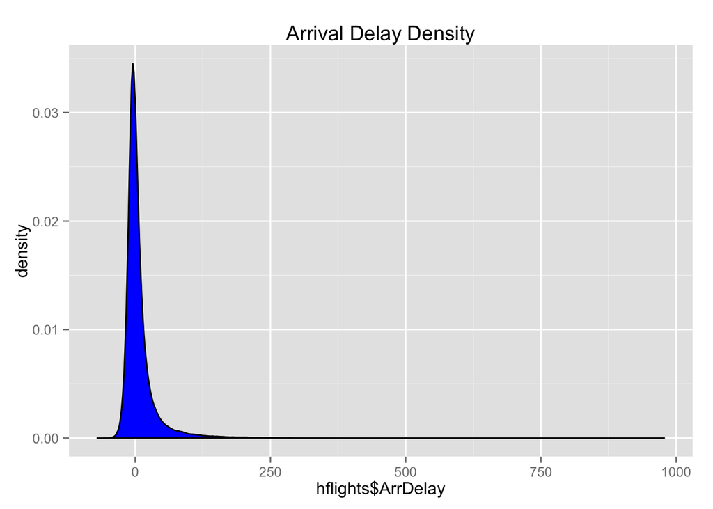

```r
ggplot(data = hflights) + geom_density(aes(x=hflights$ArrDelay), fill="blue") + ggtitle("Arrival Delay Density");
```

# 4 Probability

```r
#a P(X>x | Y>y)
val1 <- nrow(subset(hflights, x > 9 & y > 0));
val1;
```

```
## [1] 53173
```

```r
#condTotal = 223874
(val1/condTotal)/0.5;
```

```
## [1] 0.4750261
```

```r
0.25*0.50;
```

```
## [1] 0.125
```

```r
#b.
val2 <- nrow(subset(hflights, x <= 9 & y > 0));
val2;
```

```
## [1] 56401
```

```r
(val2/condTotal)/0.5;
```

```
## [1] 0.5038638
```

```r
#c
val3 <- nrow(subset(hflights, x <= 9 & y <= 0));
val3;
```

```
## [1] 106139
```

```r
(val3/condTotal)/0.5;
```

```
## [1] 0.948203
```

```r
#d
val4 <- nrow(subset(hflights, x > 9 & y <= 0));
val4;
```

```
## [1] 8161
```

```r
(val4/condTotal)/0.5;
```

```
## [1] 0.07290708
```

```r
#table
total1 <- sum(val2,val3);
total2 <- sum(val4,val1);

a <- c('<=3d quartile', '>3d quartile','Total');
b <- c(val2,val3,(total1));
c <- c(val4,val1,(total2));
d <- c((val2+val4),(val3+val1),(total1+total2));
levels <- factor(c("x/y","<=2d quartile",">2d quartile","Total"));
resultsTbl <- data.frame('x/y'=a,
                         '<=2d quartile'=b,
                         '>2d quartile'=c,
                         'Total'=d);
resultsTbl;
```

```
##             x.y X..2d.quartile X.2d.quartile  Total
## 1 <=3d quartile          56401          8161  64562
## 2  >3d quartile         106139         53173 159312
## 3         Total         162540         61334 223874
```

Does P(A|B)=P(A)P(B)?

```r
A = total2;
B = total1;

PA = A/condTotal;
PB = B/condTotal;

PA_B = PA/PB;
PA_B == PA*PB;
```

```
## [1] FALSE
```

Evaluate by running a Chi Square test for association on x and y.

```r
chisq.test(x,y);
```

```
##
##  Pearson's Chi-squared test
##
## data:  x and y
## X-squared = 24824000, df = 197270, p-value < 2.2e-16
```

# 5 Descriptive and Inferential Statistics

Provide a scatterplot of the two variables x and y

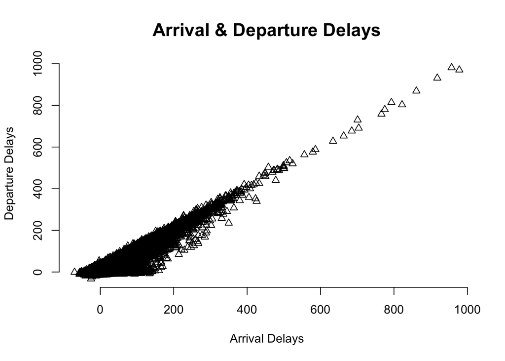

```r
plot(x, y, xlab="Arrival Delays", ylab="Departure Delays", main="Arrival & Departure Delays", pch=2, cex.main=1.5, frame.plot=FALSE);
```

Provide a 95% CI for the difference in the mean of the variables x and y

```r
t.test(y,x);
```

```
##
##  Welch Two Sample t-test
##
## data:  y and x
## t = 26.436, df = 446450, p-value < 2.2e-16
## alternative hypothesis: true difference in means is not equal to 0
## 95 percent confidence interval:
##  2.176342 2.524892
## sample estimates:
## mean of x mean of y
##  9.444951  7.094334
```

Derive a correlation matrix for two of the quantitative variables you selected. Test the hypothesis that the correlation between these variables is 0 and provide a 99% confidence interval. Discuss the meaning of your analysis.

```r
data <- data.frame(x,y);
matrix <- cor(data);
cor.test(y,x,conf.level=0.99);
```

```
##
##  Pearson's product-moment correlation
##
## data:  y and x
## t = 1189.8, df = 223870, p-value < 2.2e-16
## alternative hypothesis: true correlation is not equal to 0
## 99 percent confidence interval:
##  0.9284710 0.9299578
## sample estimates:
##       cor
## 0.9292181
```

This above shows 95% confidence that the difference in the means of x and y will be between 2.176342 and 2.524892. I conclude that correlation may exist based on the 99 percent confidence value. True correlation is not equal to 0.